# Trabalho RNA da Aula 2 - 01.03.2023

Afonso Cesar Lelis Brandão - matrícula e e-mail: 72307390@mackenzista.com.br

2023-03-07

# Primeira Parte

## Primeira questão

1. Aumente o número máximo de épocas (por exemplo, para 300) e apresente o gráfico de erro por época, como também o gráfico de sobreposição de saídas (desejada e estimada). Faça uma análise se há melhoras em relação aos valores anteriormente apresentados. Verifique o valor final de erro e veja se ele consegue chegar a 0 (zero).
- Regressão modelo

```r
# Definindo o tamanho do vetor
N<-10

# Criando o vetor X com valores de 1 a N
X<-seq(1,N)

# Criando o vetor Y com a função 2X + 3
Y<-2*X+3

# Plotando os valores de X e Y em um gráfico de pontos
plot(X,Y,type="o",xlim=c(0, 10),ylim=c(0,25))
```

[output not shown]

- Ajustes

```r
# Normalizando os vetores entre 0 e 1 e transpondo
X<-X/max(X)
Y<-Y/max(Y)
X<-t(t(X))

# Adicionando um vetor de bias à matriz X
bias<-1
X<-cbind(X,bias)

# Imprimindo as matrizes X e Y
print(X)
```

```
##           bias
##  [1,] 0.1    1
##  [2,] 0.2    1
##  [3,] 0.3    1
##  [4,] 0.4    1
##  [5,] 0.5    1
##  [6,] 0.6    1
##  [7,] 0.7    1
##  [8,] 0.8    1
##  [9,] 0.9    1
## [10,] 1.0    1
```

```r
print(cbind(Y))
```

```
##               Y
##  [1,] 0.2173913
##  [2,] 0.3043478
##  [3,] 0.3913043
##  [4,] 0.4782609
##  [5,] 0.5652174
##  [6,] 0.6521739
##  [7,] 0.7391304
##  [8,] 0.8260870
##  [9,] 0.9130435
## [10,] 1.0000000
```

- Definindo variáveis e treinando

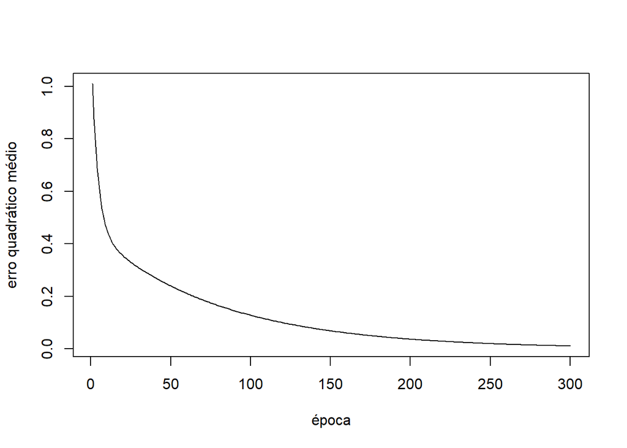

```r
# Definindo o número máximo de épocas e a taxa de aprendizado
epoca_max<-300
eta<-0.01

# Inicializando o vetor de pesos W
W<-c(0,1)

# Inicializando vetores para armazenar os erros das iterações e das épocas
err_iter<-rep(0,N)
err_epoc<-rep(0,epoca_max)

# Iniciando o loop de treinamento
for (epoca in 1:epoca_max) {
  for (i in 1:N) {
    # Calculando a saída estimada para a entrada atual
    v <- sum(X[i,]*W)
    # Calculando o erro entre a saída desejada e a saída estimada
    erro <- Y[i] - v
    # Calculando o delta para atualizar os pesos
    delta <- eta*erro*X[i,]
    # Atualizando os pesos
    W <- W + delta
    # Armazenando o erro da iteração atual
    err_iter[i] <- 0.5*(erro^2)
  }
  # Armazenando o erro da época atual
  err_epoc[epoca] <- sum(err_iter)
}

# Plotando o erro quadrático médio ao longo das épocas
plot(err_epoc, type = "line", xlab = "época", ylab = "erro quadrático médio")
```

- Pesos finais

```r
print(W)
```

```
##                bias
## 0.7146150 0.2231222
```

- Calculando a saída estimada para todas as entradas e Plotando as saídas desejadas e estimadas em um gráfico

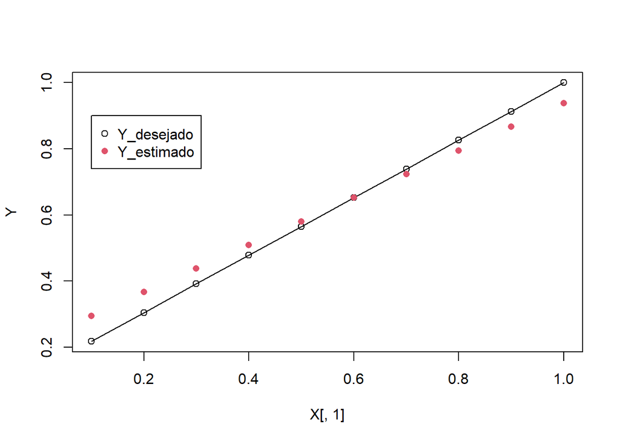

```r
Y_estimado<-X[,1]*W[1]+W[2]

plot(X[,1],Y,type ="n")
points(X[,1],Y,pch=1,type="o",col="1")
points(X[,1],Y_estimado,pch=16,type="p",col="2")
legend(0.1,0.9,legend=c("Y_desejado","Y_estimado"),col=c(1,2),pch=c(1,16))
```

```r
print(paste("Erro final do treinamento", err_epoc[epoca_max]))
```

```
## [1] "Erro final do treinamento 0.0103700261799258"
```

### Resposta

Com relação ao gráfico de sobreposição de saídas, foi possível constatar que as saídas estimadas apresentaram uma boa aproximação em relação às saídas desejadas, com discrepâncias mínimas entre elas. Esse resultado evidencia que a rede neural está realizando uma aproximação satisfatória da função que gera as saídas, contribuindo para aprimoramentos futuros no processo de treinamento.

## Segunda Questão

```r
N<-10
X<-seq(1,N)
Y<-2*X+3
plot(X,Y,type="o",xlim=c(0, 10),ylim=c(0,25))
```

[output not shown]

```r
X<-X/max(X)
Y<-Y/max(Y)
X<-t(t(X))
bias<-1
X<-cbind(X,bias)
print(X)
```

```
##           bias
##  [1,] 0.1    1
##  [2,] 0.2    1
##  [3,] 0.3    1
##  [4,] 0.4    1
##  [5,] 0.5    1
##  [6,] 0.6    1
##  [7,] 0.7    1
##  [8,] 0.8    1
##  [9,] 0.9    1
## [10,] 1.0    1
```

```r
print(cbind(Y))
```

```
##               Y
##  [1,] 0.2173913
##  [2,] 0.3043478
##  [3,] 0.3913043
##  [4,] 0.4782609
##  [5,] 0.5652174
##  [6,] 0.6521739
##  [7,] 0.7391304
##  [8,] 0.8260870
##  [9,] 0.9130435
## [10,] 1.0000000
```

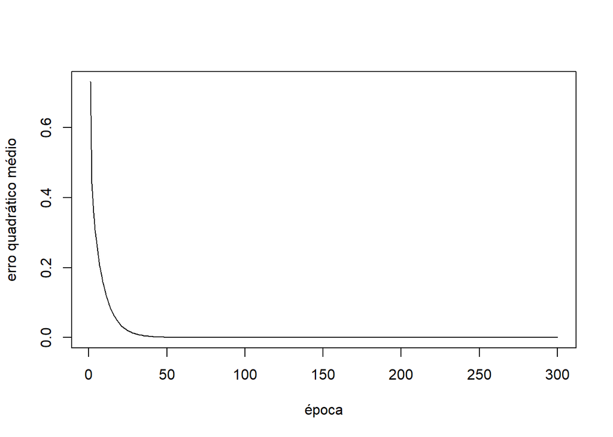

```r
epoca_max<-300
eta<-0.1
W<-c(0,1)
err_iter<-rep(0,N)
err_epoc<-rep(0,epoca_max)

for (epoca in 1:epoca_max) {
  for (i in 1:N) {
    v <- sum(X[i,]*W)
    erro <- Y[i] - v
    delta <- eta*erro*X[i,]
    W <- W + delta
    err_iter[i] <- 0.5*(erro^2)
  }
  err_epoc[epoca] <- sum(err_iter)
}
plot(err_epoc, type = "line", xlab = "época", ylab = "erro quadrático médio")
```

```r
print(W)
```

```
##                bias
## 0.8695652 0.1304348
```

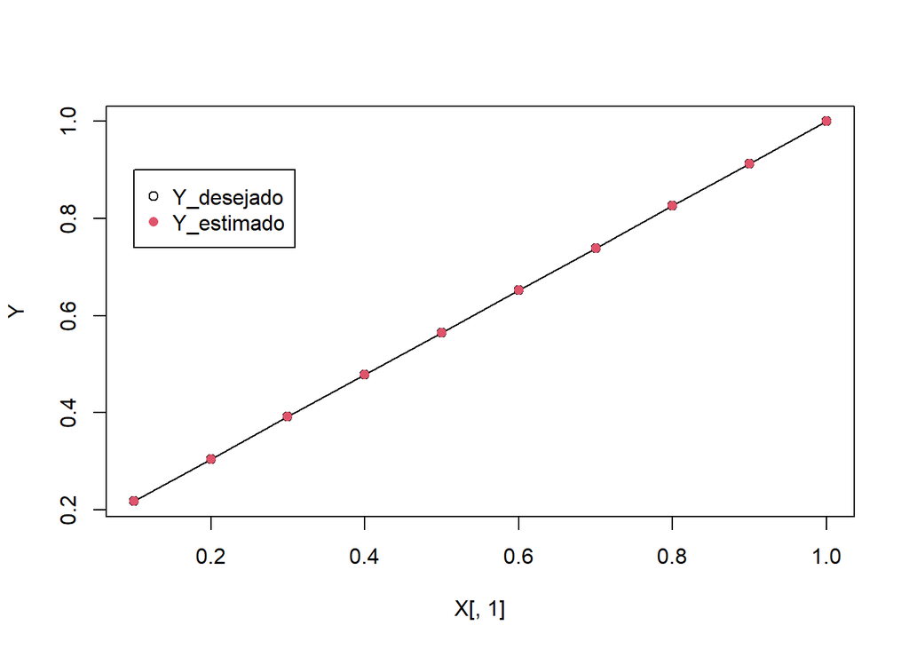

```r
Y_estimado<-X[,1]*W[1]+W[2]

plot(X[,1],Y,type ="n")
points(X[,1],Y,pch=1,type="o",col="1")
points(X[,1],Y_estimado,pch=16,type="p",col="2")
legend(0.1,0.9,legend=c("Y_desejado","Y_estimado"),col=c(1,2),pch=c(1,16))
```

```r
print(paste("Erro final do treinamento", err_epoc[epoca_max]))
```

```
## [1] "Erro final do treinamento 5.36757316768681e-18"
```

### Resposta

Ao refazer as tarefas pedidas no exercício 1, verificou-se que a rede neural apresentou um desempenho melhor em relação ao experimento anterior, tendo alcançado um valor final de erro próximo de zero e uma aproximação mais precisa entre as saídas desejadas e estimadas.

A alteração do valor do parâmetro eta afeta diretamente a taxa de aprendizado da rede neural. Quando esse valor é aumentado, a rede pode aprender mais rápido, mas também pode ocorrer o risco de que ela fique presa em mínimos locais do erro e, portanto, não consiga aprender de forma mais precisa. Isso pode afetar o desempenho geral da rede neural.